# MicroNuclei File

Natasha Karp

19/04/2020

## Exploration of the data

Visual inspection of hte data finds a significant shift between analyser and evidence of batch to batch variation. Visually the variance is not significantly different between the two analysers. Fitting a beta regression model to the control data accounting for the effect of analyser as a fixed effect and batch as a random effect delievers residues that are close to normally distributed and shown no significant hetergoeneity over the dynamic range. This indicates this model approach would be appropriate to query the data.

```r
df1=read.csv("MN_RawData_March2020.csv")
levels(df1$Experimenter)
```

```
## [1] "AA"  "AB"  "DR"  "GB"  "JT"  "MDC" "NG"  "RM"  "RV"
```

```r
levels(df1$Flow.Cytometer)
```

```
## [1] "FC500" "FT1"
```

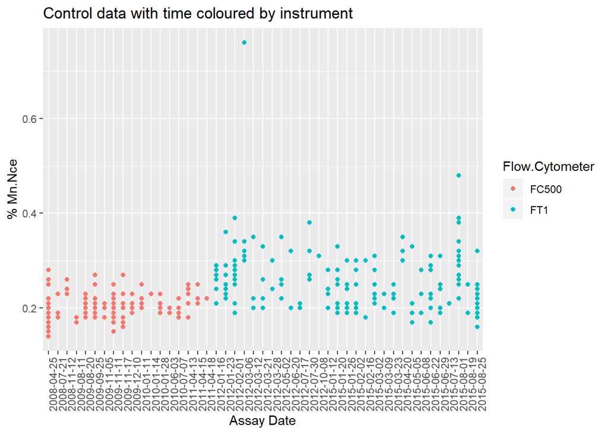

```r
GenotypesToTest=levels(df1$Genotype)[-1]
df1$Prop_MN.NCE=df1$Per_MN.NCE/100

controlData=subset(df1, df1$Genotype=="+/+")
testData=subset(df1, df1$Genotype!="+/+")

plot1 <- ggplot(data = controlData, mapping = aes_string(y="Per_MN.NCE", x = "Assay.Date", colour = "Flow.Cytometer"))
plot1<-plot1 + geom_point() +ylab("% Mn.Nce") + xlab("Assay Date")+ theme(axis.text.x = element_text(angle = 90))+ggtitle("Control data with time coloured by instrument")
plot1
```

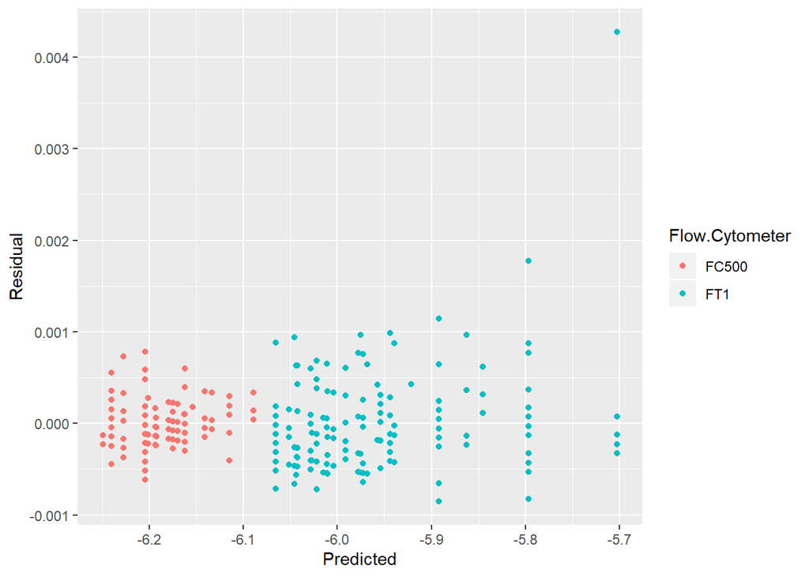

```r
#Does the variance depend on the flow Cytometer? Visually the data suggests not a significant issue.  For the size of effect interested in a minor difference is not a significant issue.
#Input of the glmmTMB for beta model is proportion from 0 to 1


EqualVar_model <- glmmTMB(Prop_MN.NCE ~ Flow.Cytometer +(1|Assay.Date) ,family=list(family="beta",link="logit"), data = controlData)
pred=predict(EqualVar_model)
res=resid(EqualVar_model)
data_all= data.frame(controlData, res, pred)
plot1 <- ggplot(data = data_all, mapping = aes_string(y="res", x = "pred", colour = "Flow.Cytometer"))
plot1 + geom_point() +ylab("Residual") + xlab("Predicted")
```

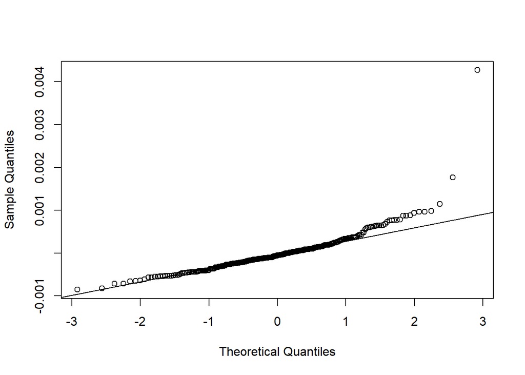

```r
qqnorm(data_all$res, main=" ")
qqline(data_all$res)
```

## Analysis pipeline 1: beta regression

A mixed linear effect beta regression model exploring the effect on Genotype on the % MN,was conducted using the R package (glmmTMB, version: 1.0.1). In detail a regression model was fited with Flow.Cytometer as a fixed effect to account for the difference arising from the instrumentation whilst assay.date was fitted as a random effect to account for the variance introduced by batch (see Equation 1)

Y~ Genotype +Flow.Cytometer+ (1|Batch) [Eq. 1]

The genotype effect and associated error were estimated as a marginal mean using the emmeans (version 1.4.4) package. The significance of the geontype effect was assessed using a likelihood ratio test. The multiple testing risk was managed by adjusting hte p values to control the false discover rate to 5% using the FDR method or the family wise error rate to 5% using the hochberg method.

```r
options(width = 500)
#Wrapper function to assess impact of Genotype

Wrapper_AssessingImpactGenotype<-function(dfControl,dfTest, parameterList){

  #empty object to colleate results too
  finalOutput=c()

   for(bob in parameterList){

     df_genotype=subset(dfTest, dfTest$Genotype==bob)
     df_combined=rbind(df_genotype,controlData)
     df_combined$Genotype=factor(df_combined$Genotype)
     df_combined$Genotype=relevel(df_combined$Genotype, ref="+/+")
     #print(levels(df_combined$Genotype))

         tryCatch(
                {
                  test_model <- glmmTMB(Prop_MN.NCE ~ Genotype + Flow.Cytometer +(1|Assay.Date) ,family=beta_family(link = "logit"), data = df_combined)
                  null_model<- glmmTMB(Prop_MN.NCE ~ Flow.Cytometer +(1|Assay.Date) ,family=beta_family(link = "logit"), data = df_combined)
                  TestSig=anova(test_model, null_model)$"Pr(>Chisq)"[2]
                  test_model_estimate=pairs(emmeans(test_model,  ~ Genotype,     adjust="none"))
                  marginalmeans=emmeans(test_model,  ~ Genotype,     adjust="none")

                  New_output=c(bob, TestSig, summary(test_model_estimate)$SE, -summary(test_model_estimate)$estimate, exp(summary(marginalmeans)$emmean[1]),exp(summary(marginalmeans)$emmean[2]))
                  names(New_output)=c("Genotype","pvalue", "Estimate_SE", "Estimate", "pred_WT", "pred_KO")

                  finalOutput=rbind(New_output, finalOutput)
                },

                error=function(e){

                    print(paste(bob, "failure", sep="_"))

                })

   }
  return(finalOutput)
}

#Wrapper_AssessingImpactGenotype(dfControl=controlData,dfTest=testData, parameterList=GenotypesToTest[2])
#output_acrossGenotypes=Wrapper_AssessingImpactGenotype(dfControl=controlData,dfTest=testData, parameterList=c("Dscc1/Dscc1"))

#output_acrossGenotypes=Wrapper_AssessingImpactGenotype(dfControl=controlData,dfTest=testData, parameterList=c("Dscc1/Dscc1", "Mcph1/Mcph1","Donson/+", "1700011A15Rik/1700011A15Rik", "1190002H23Rik/1190002H23Rik"))


Graphing<-function(WTdf,  Testdf, GenotypeInterest){
  G_data=subset(Testdf, Testdf$Genotype==GenotypeInterest)
  finalData=rbind(G_data, WTdf)
 plot1 <- ggplot(data = finalData, mapping = aes_string(y="Per_MN.NCE", x = "Assay.Date", colour="Genotype", shape = "Flow.Cytometer"))
plot1<-plot1 + geom_point() +ylab("% Mn.Nce") + xlab("Assay Date")+ theme(axis.text.x = element_text(angle = 90))+ggtitle("Control data with time coloured by instrument")
plot1

}
#Graphing(WTdf=controlData,  Testdf=testData, GenotypeInterest="1190002H23Rik/1190002H23Rik")
#Graphing(WTdf=controlData,  Testdf=testData, GenotypeInterest="Dscc1/Dscc1")
#Graphing(WTdf=controlData,  Testdf=testData, GenotypeInterest="Mcph1/Mcph1")


output_acrossGenotypes=Wrapper_AssessingImpactGenotype(dfControl=controlData,dfTest=testData, parameterList=GenotypesToTest)
setwd("C:\\Users\\KPPQ436\\Box Sync\\Quantitative Biology\\Stats_team_repo\\Natasha_Karp\\collaborations\\Gabriel Balmus\\MicronucleiAnalysis")
write.csv(output_acrossGenotypes, "outputAnalysis.csv")
output_acrossGenotypes=read.csv("outputAnalysis.csv")
output_acrossGenotypes$pval_adjust_fdr=p.adjust(output_acrossGenotypes$pvalue, method="fdr")
output_acrossGenotypes$pval_adjust_hochberg=p.adjust(output_acrossGenotypes$pvalue, method="hochberg")

nrow(output_acrossGenotypes[output_acrossGenotypes$pval_adjust_fdr<=0.05,]) #110
```

```
## [1] 110
```

```r
nrow(output_acrossGenotypes[output_acrossGenotypes$pval_adjust_hochberg<=0.05,]) #24
```

```
## [1] 24
```

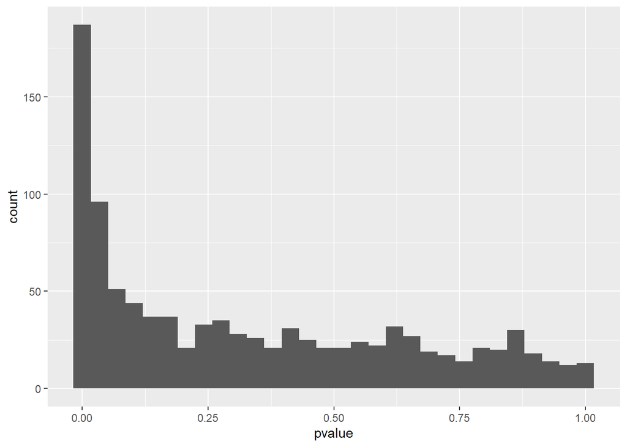

```r
ggplot(output_acrossGenotypes, aes(x=pvalue)) + geom_histogram()
```

```r
output_acrossGenotypes$direction=ifelse(output_acrossGenotypes$pval_adjust_fdr<=0.05, ifelse(output_acrossGenotypes$pred_WT>output_acrossGenotypes$pred_KO, "less", "more"),"not Sig")
output_acrossGenotypes$ES=output_acrossGenotypes$pred_KO-output_acrossGenotypes$pred_WT

sig_hochberg=subset(output_acrossGenotypes, output_acrossGenotypes$pval_adjust_hochberg<=0.05)
sig_hochberg
```

```
##              X                    Genotype       pvalue Estimate_SE   Estimate     pred_WT     pred_KO pval_adjust_fdr pval_adjust_hochberg direction            ES
## 89  New_output                     Trex1/+ 1.313411e-07  0.11084817  0.7116441 0.002299218 0.004684285    1.309471e-05         1.297650e-04      more  0.0023850665
## 102 New_output             Tnfaip1/Tnfaip1 6.242290e-12  0.07972567  0.5586038 0.002287175 0.003998507    1.037261e-09         6.192352e-09      more  0.0017113323
## 105 New_output                    Tmem98/+ 1.021197e-06  0.08636165  0.4820805 0.002299292 0.003723566    6.363337e-05         1.002816e-03      more  0.0014242738
## 131 New_output         Tatdn3(b)/Tatdn3(b) 2.008599e-09  0.12125792 -0.7490209 0.002298944 0.001087008    2.503216e-07         1.988513e-06      less -0.0012119362
## 183 New_output                   Slx4/Slx4 4.980706e-10  0.10676042  0.9017281 0.002299999 0.005666870    7.093949e-08         4.935880e-07      more  0.0033668706
## 221 New_output                    Setd1a/+ 5.512065e-07  0.08942715  0.4960057 0.002299306 0.003775802    3.925378e-05         5.423872e-04      more  0.0014764966
## 289 New_output                 Rad18/Rad18 2.745047e-07  0.07032080  0.4172407 0.002298805 0.003489052    2.280676e-05         2.706616e-04      more  0.0011902473
## 307 New_output                 Prmt7/Prmt7 1.523098e-07  0.07864837  0.4671096 0.002299003 0.003667774    1.380480e-05         1.503297e-04      more  0.0013687714
## 421 New_output                 Mysm1/Mysm1 2.676125e-06  0.11731430  0.6396672 0.002299694 0.004359874    1.482276e-04         2.622603e-03      more  0.0020601801
## 456 New_output               Mfsd2b/Mfsd2b 1.607769e-06  0.08434364  0.4624644 0.002299624 0.003651763    9.429090e-05         1.577221e-03      more  0.0013521390
## 465 New_output                 Mcph1/Mcph1 4.508220e-27  0.07205936  1.7118668 0.002308593 0.012787972    2.247348e-24         4.490187e-24      more  0.0104793785
## 481 New_output                    Mad2l2/+ 2.852770e-05  0.09488816  0.4249766 0.002298822 0.003516173    1.258391e-03         2.784303e-02      more  0.0012173517
## 486 New_output                     Lsm11/+ 2.903009e-05  0.11010404  0.5227806 0.002299847 0.003879177    1.258391e-03         2.830434e-02      more  0.0015793305
## 487 New_output                     Lsm10/+ 3.072967e-12  0.08096725  0.6180874 0.002297693 0.004263084    7.659370e-10         3.054529e-09      more  0.0019653913
## 514 New_output                   Klk9/Klk9 4.848262e-05  0.09764322 -0.3967118 0.002299232 0.001546297    2.014049e-03         4.722207e-02      less -0.0007529344
## 600 New_output       Gm13125(b)/Gm13125(b) 3.876358e-07  0.10236286 -0.5266758 0.002299261 0.001357863    2.972868e-05         3.818212e-04      less -0.0009413983
## 656 New_output                 Esco1/Esco1 1.441353e-05  0.10341072  0.4959104 0.002299692 0.003776077    7.388896e-04         1.411085e-02      more  0.0014763848
## 689 New_output                 Dscc1/Dscc1 1.105591e-32  0.05686713  1.6260408 0.002299815 0.011691584    1.102274e-29         1.102274e-29      more  0.0093917694
## 759 New_output                      Ctcf/+ 2.708465e-16  0.08953799  1.0501489 0.002310511 0.006603618    9.001132e-14         2.694923e-13      more  0.0042931067
## 807 New_output                     Cdca8/+ 5.624951e-09  0.09879488  0.6759372 0.002300132 0.004521770    6.231196e-07         5.563077e-06      more  0.0022216387
## 854 New_output           BC013712/BC013712 5.965078e-07  0.07909053  0.4271588 0.002299550 0.003524972    3.964788e-05         5.863672e-04      more  0.0012254214
## 913 New_output               Amotl1/Amotl1 1.482226e-05  0.08521342  0.4075518 0.002299516 0.003456480    7.388896e-04         1.449617e-02      more  0.0011569632
## 918 New_output                 Aldh2/Aldh2 3.972048e-12  0.10708006  0.7200706 0.002316153 0.004758717    7.920264e-10         3.944244e-09      more  0.0024425643
## 995 New_output 1190002H23Rik/1190002H23Rik 2.838156e-05  0.09155796  0.4214857 0.002299415 0.003504825    1.258391e-03         2.772878e-02      more  0.0012054096
```

```r
write.csv(output_acrossGenotypes, "output_Analysisv2.csv")
```